# Régression Multiple - Variables Qualitatives

Paul Bastide

2025-12-02

# Student t tests

## Penguins

Penguins from the Palmer Archipelago in Antartica, see [palmerpenguins](https://allisonhorst.github.io/palmerpenguins/).

```r
library(palmerpenguins)
kable(head(penguins))
```

| species | island | bill_length_mm | bill_depth_mm | flipper_length_mm | body_mass_g | sex | year |
| --- | --- | --- | --- | --- | --- | --- | --- |
| Adelie | Torgersen | 39.1 | 18.7 | 181 | 3750 | male | 2007 |
| Adelie | Torgersen | 39.5 | 17.4 | 186 | 3800 | female | 2007 |
| Adelie | Torgersen | 40.3 | 18.0 | 195 | 3250 | female | 2007 |
| Adelie | Torgersen | NA | NA | NA | NA | NA | 2007 |
| Adelie | Torgersen | 36.7 | 19.3 | 193 | 3450 | female | 2007 |
| Adelie | Torgersen | 39.3 | 20.6 | 190 | 3650 | male | 2007 |

## Subset

We keep only the penguins of species “Adelie”, and remove missing data.

```r
adelie <- subset(penguins, species == "Adelie")
adelie <- na.omit(adelie)
kable(head(adelie))
```

| species | island | bill_length_mm | bill_depth_mm | flipper_length_mm | body_mass_g | sex | year |
| --- | --- | --- | --- | --- | --- | --- | --- |
| Adelie | Torgersen | 39.1 | 18.7 | 181 | 3750 | male | 2007 |
| Adelie | Torgersen | 39.5 | 17.4 | 186 | 3800 | female | 2007 |
| Adelie | Torgersen | 40.3 | 18.0 | 195 | 3250 | female | 2007 |
| Adelie | Torgersen | 36.7 | 19.3 | 193 | 3450 | female | 2007 |
| Adelie | Torgersen | 39.3 | 20.6 | 190 | 3650 | male | 2007 |
| Adelie | Torgersen | 38.9 | 17.8 | 181 | 3625 | female | 2007 |

## Group Comparison

**Question**: Are *male* adelie penguins heavier than *female* adelie penguins ?

```r
par(mfrow = c(1, 2), mar = c(5, 4, 2, 2) + 0.1)
plot(adelie$body_mass_g, col = adelie$sex)      ## scatter plot
boxplot(body_mass_g ~ sex, data = adelie)       ## box plot
```

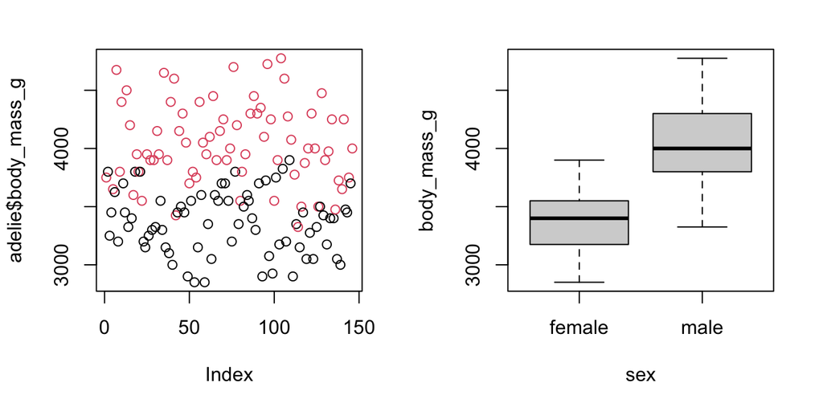

## Simple $t$ test

```r
mass_females <- subset(adelie, sex == "female")$body_mass_g
mass_males <- subset(adelie, sex == "male")$body_mass_g
t.test(mass_males, mass_females, var.equal = TRUE)
```

```
    Two Sample t-test

data:  mass_males and mass_females
t = 13.126, df = 144, p-value < 2.2e-16
alternative hypothesis: true difference in means is not equal to 0
95 percent confidence interval:
 573.0666 776.2484
sample estimates:
mean of x mean of y
 4043.493  3368.836
```

## Simple $t$ test

**Data**:

- $n_f$ female adelie penguins, $n_m$ male adelie penguins
- $y^f_{i}$: mass (g) of a female adelie penguin, $1 \leq i \leq n_f$
- $y^m_{j}$: mass (g) of a male adelie penguin, $1 \leq j \leq n_m$

**Assumption**:

- $y^f_{i} \sim \mathcal{N}(\mu_f, \sigma^2)$ iid
- $y^m_{j} \sim \mathcal{N}(\mu_m, \sigma^2)$ iid

**Test**:

$\mathcal{H}_0$: $\mu_f = \mu_m$ vs $\mathcal{H}_1$: $\mu_f \neq \mu_m$

## Simple $t$ test

**Test**:

$\mathcal{H}_0$: $\mu_f = \mu_m$ vs $\mathcal{H}_1$: $\mu_f \neq \mu_m$

**Test Statistic**:

$$T = \frac{\bar{\mathbf{y}}^f - \bar{\mathbf{y}}^m}{s_p \sqrt{\frac{1}{n_f} + \frac{1}{n_m}}}
\underset{\mathcal{H}_0}{\sim} \mathcal{T}_{n_f + n_m - 2}$$
with the “pooled” standard deviation:
$$s_p = \sqrt{\frac{(n_f-1)s^2_{\mathbf{y}^f} + (n_m-1)s^2_{\mathbf{y}^m}}{n_f + n_m - 2}}$$

## Simple $t$ test

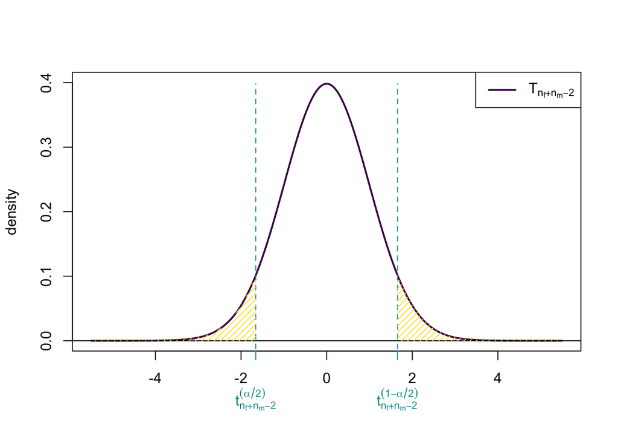

## Simple $t$ test

```r
t.test(mass_males, mass_females, var.equal = TRUE)
```

```
    Two Sample t-test

data:  mass_males and mass_females
t = 13.126, df = 144, p-value < 2.2e-16
alternative hypothesis: true difference in means is not equal to 0
95 percent confidence interval:
 573.0666 776.2484
sample estimates:
mean of x mean of y
 4043.493  3368.836
```

Reject the null that $\mu_f = \mu_m$ : males and females have different body masses.

# Linear Regression

## Model

**Assumptions**:

- $y^f_{i} \sim \mathcal{N}(\mu_f, \sigma^2)$ iid
- $y^m_{j} \sim \mathcal{N}(\mu_m, \sigma^2)$ iid

in other words:

- $y^f_{i} = \mu_f + \epsilon_i^f$, with $\epsilon^f_i \sim \mathcal{N}(0, \sigma^2)$ iid
- $y^m_{j} = \mu_m + \epsilon_j^m$, with $\epsilon^m_j \sim \mathcal{N}(0, \sigma^2)$ iid

Can we write this as a linear model: “$\mathbf{y} = \mathbf{X}\boldsymbol{\beta} + \boldsymbol{\epsilon}$” ?

## Model

Write:
$$\mathbf{y} =
\begin{pmatrix}
\mathbf{y}^f \\
\mathbf{y}^m \\
\end{pmatrix}
\quad
\text{and}
\quad
\boldsymbol{\epsilon} =
\begin{pmatrix}
\boldsymbol{\epsilon}^f \\
\boldsymbol{\epsilon}^m \\
\end{pmatrix}$$
$\mathbf{y}$ and $\boldsymbol{\epsilon}$ vectors of size $n = n_f + n_m$.

Then, for $1 \leq i \leq n$:
$$y_i = \mu_k + \epsilon_i
\quad
\text{with}
\quad
\begin{cases}
\mu_k = \mu_f & \text{if } 1 \leq i \leq n_f\\
\mu_k = \mu_m & \text{if } n_f+1 \leq i \leq n_f + n_m
\end{cases}$$

Regression matrix $\mathbf{X}$ ?

## Linear Model

$$\text{Write:}
\qquad
\mathbf{X} =
\begin{pmatrix}
1 & 0 \\
\vdots & \vdots \\
1 & 0 \\
0 & 1 \\
\vdots & \vdots\\
0 & 1 \\
\end{pmatrix}
\begin{matrix}
\\
n_f\\
\\
\\
n_m\\
\\
\end{matrix}
\qquad
\text{and}
\qquad
\boldsymbol{\beta} =
\begin{pmatrix}
\mu_f \\
\mu_m \\
\end{pmatrix}$$

$$\text{Then:}
\qquad
\mathbf{X}\boldsymbol{\beta}
=
\begin{pmatrix}
\mu_f + 0\\
\vdots \\
\mu_f + 0\\
0 + \mu_m\\
\vdots\\
0 + \mu_m \\
\end{pmatrix}
=
\begin{pmatrix}
\mu_f \\
\vdots \\
\mu_f \\
\mu_m \\
\vdots\\
\mu_m \\
\end{pmatrix}
\begin{matrix}
\\
n_f\\
\\
\\
n_m\\
\\
\end{matrix}$$

## Linear Model

Hence, the model can be written as:
$$\begin{pmatrix}
y^f_1 \\
\vdots\\
y^f_{n_f} \\
y^m_{1} \\
\vdots\\
y^m_{n_m} \\
\end{pmatrix}
=
\begin{pmatrix}
1 & 0 \\
\vdots & \vdots \\
1 & 0 \\
0 & 1 \\
\vdots & \vdots\\
0 & 1 \\
\end{pmatrix}
\begin{pmatrix}
\mu_f \\
\mu_m \\
\end{pmatrix}
+
\begin{pmatrix}
\epsilon^f_1 \\
\vdots\\
\epsilon^f_{n_f} \\
\epsilon^m_{1} \\
\vdots\\
\epsilon^m_{n_m} \\
\end{pmatrix}$$

i.e:
$$\mathbf{y} = \mathbf{X}\boldsymbol{\beta} + \boldsymbol{\epsilon}
\quad \text{with} \quad \boldsymbol{\epsilon} \sim \mathcal{N}(\mathbf{0}, \sigma^2 \mathbf{I}_n)$$

$\to$ classical linear model with Gaussian assumption !

## Linear Model - With Intercept

$$\text{Write:}
\qquad
\mathbf{X} =
\begin{pmatrix}
1 & 0 \\
\vdots & \vdots \\
1 & 0 \\
1 & 1 \\
\vdots & \vdots\\
1 & 1 \\
\end{pmatrix}
\begin{matrix}
\\
n_f\\
\\
\\
n_m\\
\\
\end{matrix}
\qquad
\text{and}
\qquad
\boldsymbol{\beta} =
\begin{pmatrix}
\mu_f \\
\mu_m - \mu_f \\
\end{pmatrix}$$

$$\text{Then:}
\qquad
\mathbf{X}\boldsymbol{\beta}
=
\begin{pmatrix}
\mu_f + 0\\
\vdots \\
\mu_f + 0\\
\mu_f + \mu_m - \mu_f\\
\vdots\\
\mu_f + \mu_m - \mu_f \\
\end{pmatrix}
=
\begin{pmatrix}
\mu_f \\
\vdots \\
\mu_f \\
\mu_m \\
\vdots\\
\mu_m \\
\end{pmatrix}
\begin{matrix}
\\
n_f\\
\\
\\
n_m\\
\\
\end{matrix}$$

## Linear Model - With Intercept

The model can also be written as:
$$\begin{pmatrix}
y^f_1 \\
\vdots\\
y^f_{n_f} \\
y^m_{1} \\
\vdots\\
y^m_{n_m} \\
\end{pmatrix}
=
\begin{pmatrix}
1 & 0 \\
\vdots & \vdots \\
1 & 0 \\
1 & 1 \\
\vdots & \vdots\\
1 & 1 \\
\end{pmatrix}
\begin{pmatrix}
\mu_f \\
\mu_m - \mu_f \\
\end{pmatrix}
+
\begin{pmatrix}
\epsilon^f_1 \\
\vdots\\
\epsilon^f_{n_f} \\
\epsilon^m_{1} \\
\vdots\\
\epsilon^m_{n_m} \\
\end{pmatrix}$$

i.e:
$$\mathbf{y} = \mathbf{X}\boldsymbol{\beta} + \boldsymbol{\epsilon}
\quad \text{with} \quad \boldsymbol{\epsilon} \sim \mathcal{N}(\mathbf{0}, \sigma^2 \mathbf{I}_n)$$

$\to$ parametrization used in `R`

## Linear Model - $t$ test

$$\mathbf{y} = \mathbf{X}\boldsymbol{\beta} + \boldsymbol{\epsilon}
\quad \text{with} \quad \boldsymbol{\epsilon} \sim \mathcal{N}(\mathbf{0}, \sigma^2 \mathbf{I}_n)$$

As
$$\boldsymbol{\beta} =
\begin{pmatrix}
\mu_f \\
\mu_m - \mu_f \\
\end{pmatrix},$$

the test
$$\mathcal{H}_0: \mu_f = \mu_m \quad \text{vs} \quad \mathcal{H}_1: \mu_f \neq \mu_m$$

becomes:
$$\mathcal{H}_0: \beta_2 = 0 \quad \text{vs} \quad \mathcal{H}_1: \beta_2 \neq 0$$

$\to$ $t$-test on the $\beta_2$ coefficient !

## Linear Model

```r
fit <- lm(body_mass_g ~ sex, data = adelie)
```

```r
model.matrix(fit)[1:10, ]
```

```
   (Intercept) sexmale
1            1       1
2            1       0
3            1       0
4            1       0
5            1       1
6            1       0
7            1       1
8            1       0
9            1       1
10           1       1
```

## Linear Model

```r
summary(fit)
```

```
Call:
lm(formula = body_mass_g ~ sex, data = adelie)

Residuals:
    Min      1Q  Median      3Q     Max
-718.49 -218.84  -18.84  225.00  731.51

Coefficients:
            Estimate Std. Error t value Pr(>|t|)
(Intercept)  3368.84      36.34   92.69   <2e-16 ***
sexmale       674.66      51.40   13.13   <2e-16 ***
---
Signif. codes:  0 '***' 0.001 '**' 0.01 '*' 0.05 '.' 0.1 ' ' 1

Residual standard error: 310.5 on 144 degrees of freedom
Multiple R-squared:  0.5447,    Adjusted R-squared:  0.5416
F-statistic: 172.3 on 1 and 144 DF,  p-value: < 2.2e-16
```

## Simple $t$ test

```r
t.test(mass_males, mass_females, var.equal = TRUE)
```

```
    Two Sample t-test

data:  mass_males and mass_females
t = 13.126, df = 144, p-value < 2.2e-16
alternative hypothesis: true difference in means is not equal to 0
95 percent confidence interval:
 573.0666 776.2484
sample estimates:
mean of x mean of y
 4043.493  3368.836
```

## Test statistics

**Simple $t$ test**:
$$T = \frac{\bar{\mathbf{y}}^f - \bar{\mathbf{y}}^m}{s_p \sqrt{\frac{1}{n_f} + \frac{1}{n_m}}}
\underset{\mathcal{H}_0}{\sim} \mathcal{T}_{n_f + n_m - 2}
\quad
\text{with}
\quad
s_p = \sqrt{\frac{(n_f-1)s^2_{\mathbf{y}^f} + (n_m-1)s^2_{\mathbf{y}^m}}{n_f + n_m - 2}}$$

**Linear Regression**:
$$\frac{\hat{\beta}_k - \beta_k}{\sqrt{\hat{\sigma}^2 [(\mathbf{X}^T\mathbf{X})^{-1}]_{kk}}}
\sim
\mathcal{T}_{n-p}
\quad
\text{with}
\quad
p = 2
~,~
n = n_f + n_m
~,~
\beta_2 = 0 \text{ under } \mathcal{H}_0$$

i.e.
$$\frac{\hat{\beta}_2}{\sqrt{\hat{\sigma}^2 [(\mathbf{X}^T\mathbf{X})^{-1}]_{22}}}
\underset{\mathcal{H}_0}{\sim} \mathcal{T}_{n_f + n_m - 2}$$

## Test statistics

Let’s show that:
$$\frac{\hat{\beta}_2}{\sqrt{\hat{\sigma}^2 [(\mathbf{X}^T\mathbf{X})^{-1}]_{22}}}
\quad
\text{with}
\quad
\mathbf{X} =
\begin{pmatrix}
1 & 0 \\
\vdots & \vdots \\
1 & 0 \\
1 & 1 \\
\vdots & \vdots\\
1 & 1 \\
\end{pmatrix}
\begin{matrix}
\\
n_f\\
\\
\\
n_m\\
\\
\end{matrix}
\qquad
\text{and}
\qquad
\boldsymbol{\beta} =
\begin{pmatrix}
\mu_f \\
\mu_m - \mu_f \\
\end{pmatrix}$$

is equal to
$$\frac{\bar{\mathbf{y}}^f - \bar{\mathbf{y}}^m}{s_p \sqrt{\frac{1}{n_f} + \frac{1}{n_m}}}
\quad
\text{with}
\quad
s_p = \sqrt{\frac{(n_f-1)s^2_{\mathbf{y}^f} + (n_m-1)s^2_{\mathbf{y}^m}}{n_f + n_m - 2}}$$

## Test statistics - Proof - 1/5

$$\mathbf{X}^T\mathbf{X} =
\begin{pmatrix}
1 & \cdots & 1 & 1 & \cdots & 1 \\
0 & \cdots & 0 & 1 & \cdots & 1 \\
\end{pmatrix}
\begin{pmatrix}
1 & 0 \\
\vdots & \vdots \\
1 & 0 \\
1 & 1 \\
\vdots & \vdots\\
1 & 1 \\
\end{pmatrix}
=
\begin{pmatrix}
n & n_m \\
n_m & n_m
\end{pmatrix}$$

Hence:
$$(\mathbf{X}^T\mathbf{X})^{-1}
=
\begin{pmatrix}
n & n_m \\
n_m & n_m
\end{pmatrix}^{-1}
=
\frac{1}{nn_m - n_m^2}
\begin{pmatrix}
n_m & -n_m \\
-n_m & n
\end{pmatrix}$$

$$[(\mathbf{X}^T\mathbf{X})^{-1}]_{22}
= \frac{n}{nn_m - n_m^2}
= \frac{n_f + n_m}{(n - n_m)n_m}
= \frac{n_f + n_m}{n_f n_m}
= \frac{1}{n_f} + \frac{1}{n_m}$$

## Test statistics - Proof - 2/5

$$\hat{\boldsymbol{\beta}}
= (\mathbf{X}^{T}\mathbf{X})^{-1}\mathbf{X}^{T}\mathbf{y}$$

But:
$$\mathbf{X}^{T}\mathbf{y}
=
\begin{pmatrix}
1 & \cdots & 1 & 1 & \cdots & 1 \\
0 & \cdots & 0 & 1 & \cdots & 1 \\
\end{pmatrix}
\mathbf{y}
=
\begin{pmatrix}
\sum_{i = 1}^n y_i\\
\sum_{j = 1}^{n_m} y^m_j
\end{pmatrix}$$

Hence:
$$\begin{aligned}
\hat{\boldsymbol{\beta}}
& = (\mathbf{X}^{T}\mathbf{X})^{-1}\mathbf{X}^{T}\mathbf{y}
=
\frac{1}{n_fn_m}
\begin{pmatrix}
n_m & -n_m \\
-n_m & n
\end{pmatrix}
\begin{pmatrix}
\sum_{i = 1}^n y_i\\
\sum_{j = 1}^{n_m} y^m_j
\end{pmatrix} \\
&=
%\frac{1}{n_fn_m}
%\begin{pmatrix}
%n_m\sum_{i = 1}^n y_i - n_m\sum_{j = 1}^{n_m} y^m_j\\
%- n_m\sum_{i = 1}^{n} y_i + n\sum_{j = 1}^{n_m} y^m_j\\
%\end{pmatrix}
%=
\frac{1}{n_fn_m}
\begin{pmatrix}
n_m\sum_{i = 1}^n y_i - n_m\sum_{j = 1}^{n_m} y^m_j\\
- n_m\sum_{i = 1}^{n} y_i + n_m\sum_{j = 1}^{n_m} y^m_j + n_f\sum_{j = 1}^{n_m} y^m_j\\
\end{pmatrix} \\
&=
\frac{1}{n_fn_m}
\begin{pmatrix}
n_m \sum_{i = 1}^{n_f} y^f_i\\
- n_m\sum_{i = 1}^{n_f} y^f_i + n_f\sum_{j = 1}^{n_m} y^m_j\\
\end{pmatrix}
\end{aligned}$$

## Test statistics - Proof - 3/5

$$\hat{\boldsymbol{\beta}}
= (\mathbf{X}^{T}\mathbf{X})^{-1}\mathbf{X}^{T}\mathbf{y}$$

And:
$$\hat{\boldsymbol{\beta}}
=
\frac{1}{n_fn_m}
\begin{pmatrix}
n_m \sum_{i = 1}^{n_f} y^f_i\\
- n_m\sum_{i = 1}^{n_f} y^f_i + n_f\sum_{j = 1}^{n_m} y^m_j\\
\end{pmatrix}
=
\begin{pmatrix}
\bar{\mathbf{y}}^f\\
-\bar{\mathbf{y}}^f + \bar{\mathbf{y}}^m\\
\end{pmatrix}$$

*Note*:
$$\text{since }
\quad
\boldsymbol{\beta} =
\begin{pmatrix}
\mu_f \\
\mu_m - \mu_f \\
\end{pmatrix}
\quad
\text{this result is coherent.}$$

*Note*:
$$\text{As}
\quad
\mathbf{x}^{i} =
\begin{cases}
(1~0) & \text{ if $i$ female} \\
(1~1) & \text{ if $i$ male} \\
\end{cases}
\quad
\text{we get:}
\quad
\hat{y}_i = \mathbf{x}^{i}\hat{\boldsymbol{\beta}} =
\begin{cases}
\bar{\mathbf{y}}^f & \text{ if $i$ female} \\
\bar{\mathbf{y}}^m & \text{ if $i$ male} \\
\end{cases}$$

## Test statistics - Proof - 4/5

$$\hat{\sigma}^2 = \frac{1}{n - 2}\sum_{i = 1}^n (y_i - \hat{y}_i)^2$$

Hence:
$$\hat{\sigma}^2 = \frac{1}{n_f + n_m - 2}
\left[
\sum_{i = 1}^{n_f} (y^f_i - \bar{\mathbf{y}}^f)^2 +
\sum_{i = 1}^{n_m} (y^m_i - \bar{\mathbf{y}}^m)^2
\right]$$

Recall:
$$s^2_p = \frac{(n_f-1)s^2_{\mathbf{y}^f} + (n_m-1)s^2_{\mathbf{y}^m}}{n_f + n_m - 2}$$

hence:
$$\hat{\sigma}^2 = s^2_p.$$

## Test statistics - Proof - 5/5

$$T = \frac{\hat{\beta}_2}{\sqrt{\hat{\sigma}^2 [(\mathbf{X}^T\mathbf{X})^{-1}]_{22}}}$$

but:
$$\hat{\beta}_2 = \bar{\mathbf{y}}^m -\bar{\mathbf{y}}^f \\
\hat{\sigma}^2 = s^2_p \\
[(\mathbf{X}^T\mathbf{X})^{-1}]_{22} = \frac{1}{n_f} + \frac{1}{n_m}$$

hence:
$$T = \frac{\bar{\mathbf{y}}^f - \bar{\mathbf{y}}^m}{s_p \sqrt{\frac{1}{n_f} + \frac{1}{n_m}}}$$

And the simple $t$-test is the same as the $t$-test on the coefficient of the linear regression.

## Summary

**Group comparison**:

- $n_f$ female adelie penguins, $n_m$ male adelie penguins
- $y^f_{i}$: mass (g) of a female adelie penguin, $1 \leq i \leq n_f$, $y^f_{i} \sim \mathcal{N}(\mu_f, \sigma^2)$ iid
- $y^m_{j}$: mass (g) of a male adelie penguin, $1 \leq j \leq n_m$, $y^m_{j} \sim \mathcal{N}(\mu_m, \sigma^2)$ iid
- $\mathcal{H}_0$: $\mu_f = \mu_m$ vs $\mathcal{H}_1$: $\mu_f \neq \mu_m$

is the same as a **Linear model** with:

- $\mathbf{y} = \mathbf{X}\boldsymbol{\beta} + \boldsymbol{\epsilon}$ with $\boldsymbol{\epsilon} \sim \mathcal{N}(\mathbf{0}, \sigma^2 \mathbf{I}_n)$
- $\mathbf{X}_1 = \mathbb{1}_n$ and $\mathbf{X}_2 = \mathbb{1}(male)$
- $\beta_1 = \mu_f$ and $\beta_2 = \mu_m - \mu_f$.
- $\mathcal{H}_0: \beta_2 = 0$ vs $\mathcal{H}_1: \beta_2 \neq 0$

$\to$ what happens when there are more than two groups ?

# One-way ANOVA

## Species

We keep only the females penguins of any species, and remove missing data.

```r
females <- subset(penguins, sex == "female")
females <- na.omit(females)
kable(females[c(1, 2, 101, 102, 151, 152), ])
```

| species | island | bill_length_mm | bill_depth_mm | flipper_length_mm | body_mass_g | sex | year |
| --- | --- | --- | --- | --- | --- | --- | --- |
| Adelie | Torgersen | 39.5 | 17.4 | 186 | 3800 | female | 2007 |
| Adelie | Torgersen | 40.3 | 18.0 | 195 | 3250 | female | 2007 |
| Gentoo | Biscoe | 43.8 | 13.9 | 208 | 4300 | female | 2008 |
| Gentoo | Biscoe | 43.2 | 14.5 | 208 | 4450 | female | 2008 |
| Chinstrap | Dream | 46.9 | 16.6 | 192 | 2700 | female | 2008 |
| Chinstrap | Dream | 46.2 | 17.5 | 187 | 3650 | female | 2008 |

## Species

**Question**: are the females of each species of different body mass ?

```r
par(mfrow = c(1, 2), mar = c(5, 4, 2, 2) + 0.1)
plot(females$body_mass_g, col = females$species)     ## scatter plot
boxplot(body_mass_g ~ species, data = females)       ## box plot
```

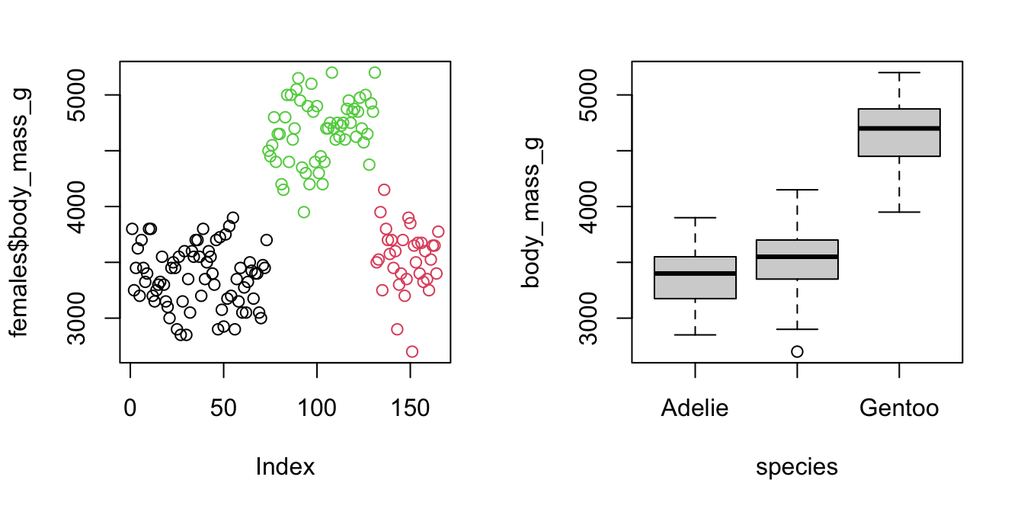

## $t$ tests

Pairwise $t$ tests:

```r
pairwise.t.test(females$body_mass_g, females$species,
                p.adjust.method = "none")
```

```
    Pairwise comparisons using t tests with pooled SD

data:  females$body_mass_g and females$species

          Adelie Chinstrap
Chinstrap 0.0066 -
Gentoo    <2e-16 <2e-16

P value adjustment method: none
```

$\to$ ${K \choose 2}$ tests : Multiple testing problems.

## $t$ tests - Model

**Model**:

- $n_s$ penguins, for species $s \in S = \{adelie, chinstrap, gentoo\}$
- $y^s_{i}$: mass (g) of a female penguin of species $s$, $1 \leq i \leq n_s$
- $y^s_{i} \sim \mathcal{N}(\mu_s, \sigma^2)$ iid for any species $s$.

**Pairwise Tests**:

$$\mathcal{H}^{s_1,s_2}_0:~ \mu_{s_1} = \mu_{s_2} \quad \text{vs} \quad \mathcal{H}^{s_1,s_2}_1:~\mu_{s_1} \neq \mu_{s_2}
\text{ for any pair } (s_1,s_2) \text{ of species}.$$

**Global Tests** can we do ?

$$\mathcal{H}_0:~\mu_a = \mu_c = \mu_g \quad \text{vs} \quad \mathcal{H}_1:~\exists s_1, s_2 \in S ~|~ \mu_{s_1} \neq \mu_{s_2} ?$$

## One-way ANOVA

- $S$ a set of $|S| = K$ groups;
- $\mathbf{y}$ the vector of all data, length $n = \sum_{k=1}^K n_k$;
- $\mathbf{X}$ the matrix of size $n \times K$, such that:
  - $\mathbf{X}_1 = \mathbb{1}_{n}$ is the intercept (vector column)
  - $\mathbf{X}_k = \mathbb{1}(S_k)$ the indicator of group $k$, $2 \leq k \leq K$.
    - $x_{ik} = 1$ if individual $i$ is in group $k$, and $0$ otherwise.
- $\boldsymbol{\beta}$ the vector of mean differences, of length $K$:
  - $\beta_1 = \mu_1$
  - $\beta_k = \mu_k - \mu_1$
- **the first group is the reference**

## One-way ANOVA

$$\begin{pmatrix}
y^1_1 \\
\vdots\\
y^1_{n_1} \\
y^2_{1} \\
\vdots\\
y^2_{n_2} \\
\vdots\\
y^K_{1} \\
\vdots\\
y^K_{n_K} \\
\end{pmatrix}
=
\begin{pmatrix}
1 & 0 & 0 & \cdots & 0\\
\vdots & \vdots & \vdots & \cdots & \vdots\\
1 & 0 & 0 & \cdots & 0\\
1 & 1 & 0 & \cdots & 0\\
\vdots & \vdots & \vdots & \cdots & \vdots\\
1 & 1 & 0 & \cdots & 0\\
\vdots & \vdots & \vdots & \cdots & \vdots\\
1 & 0 & 0 & \cdots & 1\\
\vdots & \vdots & \vdots & \cdots & \vdots\\
1 & 0 & 0 & \cdots & 1\\
\end{pmatrix}
\begin{pmatrix}
\mu_1 \\
\mu_2 - \mu_1 \\
\vdots\\
\mu_K - \mu_1 \\
\end{pmatrix}
+
\begin{pmatrix}
\epsilon^1_1 \\
\vdots\\
\epsilon^1_{n_1} \\
\epsilon^2_{1} \\
\vdots\\
\epsilon^2_{n_2} \\
\vdots\\
\epsilon^K_{1} \\
\vdots\\
\epsilon^K_{n_K} \\
\end{pmatrix}$$

## One-way ANOVA

**Model**:

$$\mathbf{y} = \mathbf{X}\boldsymbol{\beta} + \boldsymbol{\epsilon}
\quad \text{with} \quad \boldsymbol{\epsilon} \sim \mathcal{N}(\mathbf{0}, \sigma^2 \mathbf{I}_n)$$

**Note**: Assuming that the groups are disjoint, $\text{rg}(X) = K$.

This is equivalent to the following model:
$$\begin{aligned}
y_i &= \beta_1 + \epsilon_i = \mu_1 + \epsilon_i
& \text{ if } &i \text{ is in group } 1\\
y_i &= \beta_1 + \beta_k + \epsilon_i
= \mu_k + \epsilon_i
& \text{ if } &i \text{ is in group } k,\ k>1 \\
\end{aligned}$$

i.e. each group has a mean $\mu_k$, and the errors are Gaussian iid.

## Species

```r
fit <- lm(body_mass_g ~ species, data = females)
model.matrix(fit)[c(1, 2, 101, 102, 151, 152), ]
```

```
    (Intercept) speciesChinstrap speciesGentoo
1             1                0             0
2             1                0             0
101           1                0             1
102           1                0             1
151           1                1             0
152           1                1             0
```

## Species

```r
summary(fit)
```

```
Call:
lm(formula = body_mass_g ~ species, data = females)

Residuals:
    Min      1Q  Median      3Q     Max
-827.21 -193.84   20.26  181.16  622.79

Coefficients:
                 Estimate Std. Error t value Pr(>|t|)
(Intercept)       3368.84      32.42 103.908  < 2e-16 ***
speciesChinstrap   158.37      57.52   2.754  0.00657 **
speciesGentoo     1310.91      48.72  26.904  < 2e-16 ***
---
Signif. codes:  0 '***' 0.001 '**' 0.01 '*' 0.05 '.' 0.1 ' ' 1

Residual standard error: 277 on 162 degrees of freedom
Multiple R-squared:  0.8292,    Adjusted R-squared:  0.8271
F-statistic: 393.2 on 2 and 162 DF,  p-value: < 2.2e-16
```

## One-way ANOVA - Coefficients

It is easy to show that:

$$\hat{\beta}_1 = \bar{\mathbf{y}}^{s_1}\\
\hat{\beta}_k = \bar{\mathbf{y}}^{s_k} - \bar{\mathbf{y}}^{s_1} \text{ for } 2 \leq k \leq K\\$$
Hence:

- $\hat{\beta}_1$ is the estimator of the mean of the first group;
- $\hat{\beta}_k$ is the estimator of the **difference** between the mean of group $k$ and the first group ($k > 1$).

## One-way ANOVA - Coefficients

We have:
$$\boldsymbol{\beta} =
\begin{pmatrix}
\mu_{s_1}\\
\mu_{s_2} - \mu_{s_1}\\
\vdots\\
\mu_{s_K} - \mu_{s_1}\\
\end{pmatrix}
\quad
\text{and}
\quad
\hat{\boldsymbol{\beta}} =
\begin{pmatrix}
\bar{\mathbf{y}}^{s_1}\\
\bar{\mathbf{y}}^{s_2} - \bar{\mathbf{y}}^{s_1}\\
\vdots\\
\bar{\mathbf{y}}^{s_K} - \bar{\mathbf{y}}^{s_1}\\
\end{pmatrix}$$

- The $t$ test on the coefficient $\beta_k$:

$$\mathcal{H}^{k}_0: \beta_{k} = 0 \quad{ vs } \quad \mathcal{H}^{k}_1: \beta_{k} \neq 0$$

is the same as the test of the **difference** between groups $1$ & $k$:

$$\mathcal{H}^{1,k}_0: \mu_{1} = \mu_{k} \quad{ vs } \quad \mathcal{H}^{1,k}_1: \mu_{1} \neq \mu_{k}$$

## One-way ANOVA - Global Test

We have:
$$\boldsymbol{\beta} =
\begin{pmatrix}
\mu_{s_1}\\
\mu_{s_2} - \mu_{s_1}\\
\vdots\\
\mu_{s_K} - \mu_{s_1}\\
\end{pmatrix}
\quad
\text{and}
\quad
\hat{\boldsymbol{\beta}} =
\begin{pmatrix}
\bar{\mathbf{y}}^{s_1}\\
\bar{\mathbf{y}}^{s_2} - \bar{\mathbf{y}}^{s_1}\\
\vdots\\
\bar{\mathbf{y}}^{s_K} - \bar{\mathbf{y}}^{s_1}\\
\end{pmatrix}$$

- The global $F$ test on the coefficients $\beta_2, \dotsc, \beta_K$:

$$\mathcal{H}_0: \beta_{2} = \beta_3 = \cdots = \beta_{K} = 0 \quad{ vs } \quad \mathcal{H}_1: \exists k | \beta_{k} \neq 0$$

is the same as the global test of mean **equality of all groups**:

$$\mathcal{H}_0: \mu_{1} = \mu_2 = \cdots = \mu_{K} \quad{ vs } \quad \mathcal{H}_1: \exists k, k' | \mu_{k} \neq \mu_{k'}$$

## Species

```r
fit <- lm(body_mass_g ~ species, data = females)
summary(fit)
```

```
Call:
lm(formula = body_mass_g ~ species, data = females)

Residuals:
    Min      1Q  Median      3Q     Max
-827.21 -193.84   20.26  181.16  622.79

Coefficients:
                 Estimate Std. Error t value Pr(>|t|)
(Intercept)       3368.84      32.42 103.908  < 2e-16 ***
speciesChinstrap   158.37      57.52   2.754  0.00657 **
speciesGentoo     1310.91      48.72  26.904  < 2e-16 ***
---
Signif. codes:  0 '***' 0.001 '**' 0.01 '*' 0.05 '.' 0.1 ' ' 1

Residual standard error: 277 on 162 degrees of freedom
Multiple R-squared:  0.8292,    Adjusted R-squared:  0.8271
F-statistic: 393.2 on 2 and 162 DF,  p-value: < 2.2e-16
```

# One-way ANOVA - Parametrization

## General Model

In general, we might write for observation $i$ of group $k$:
$$y_{i,k} = \mu + \beta_k + \epsilon_i$$

- $\mu$ would be the “grand mean” (intercept)
- $\beta_k$ the specific effect of group $k$ ($1 \leq k \leq K$).

## General Model Over-Parametrization

$$y_{i,k} = \mu + \beta_k + \epsilon_i$$

The model has $K+1$ parameters.

The associated regression matrix would be:
$$\mathbf{X} = (\mathbb{1}, \mathbb{1}(S_1), \dotsc, \mathbb{1}(S_K))$$

$\mathbf{X}$ is **not of full rank**: $\mathbb{1} = \sum_{k=1}^K \mathbb{1}(S_k)$.

## Exemple with two groups

$$\mathbf{X} =
\begin{pmatrix}
1 & 1 & 0 \\
\vdots & \vdots & \vdots \\
1 & 1 & 0 \\
1 & 0 & 1 \\
\vdots & \vdots & \vdots\\
1 & 0 & 1 \\
\end{pmatrix}$$

**We need some constraint on the parameters**.

## Constraint : Group 1 as reference

$$y_{i,k} = \mu + \beta_k + \epsilon_i$$

In the previous studies, we assumed
$$\beta_1 = 0$$

- group 1 has the “reference” mean $\mu$
- group $k>1$ has mean $\mu + \beta_k$
- $\beta_k = \mu_k - \mu_1$ is the difference between group 1 and $k$.
- $\mathbf{X} = (\mathbb{1}, \mathbb{1}(S_2), \dotsc, \mathbb{1}(S_K))$ is full rank.

$\to$ This is the constraint used by default in `R`.

## Constraint : No intercept

$$y_{i,k} = \mu + \beta_k + \epsilon_i$$

We can assume
$$\mu = 0$$

- $\beta_k = \mu_k$ models the mean of group $k$ directly.
- $\mathbf{X} = (\mathbb{1}(S_1), \dotsc, \mathbb{1}(S_K))$ is full rank.
- estimators of $\beta_k$ are changed, but not the estimator of $\sigma^2$, nor the fitted values.

## Constraint : Null Sum

$$y_{i,k} = \mu + \beta_k + \epsilon_i$$

We can assume
$$\sum_{k = 1}^K \beta_k= 0
\qquad \text{i.e.} \qquad
\beta_K = - \sum_{k = 1}^{K-1} \beta_k$$

- $\mathbf{X} = (\mathbb{1}, \mathbb{1}(S_1) - \mathbb{1}(S_K), \dotsc, \mathbb{1}(S_{K-1}) - \mathbb{1}(S_K))$ is full rank.
- estimators of $\mu$, $\beta_k$ are changed, but not the estimator of $\sigma^2$, nor the fitted values.

## Constraint : Weighted Null Sum

$$y_{i,k} = \mu + \beta_k + \epsilon_i$$

We can assume
$$\sum_{k = 1}^K n_k \beta_k= 0
\qquad \text{i.e.} \qquad
\beta_K = -\frac{1}{n_K} \sum_{k = 1}^{K-1} n_k \beta_k$$

- $\mathbf{X} = (\mathbb{1}, \mathbb{1}(S_1) - \frac{n_1}{n_K}\mathbb{1}(S_K), \dotsc, \mathbb{1}(S_{K-1}) - \frac{n_{K-1}}{n_K}\mathbb{1}(S_K))$ is full rank.
- estimators of $\mu$, $\beta_k$ are changed, but not the estimator of $\sigma^2$, nor the fitted values.

# One-way ANOVA table

## One-way ANOVA - $F$ test

$$y_{i,k} = \mu + \beta_k + \epsilon_i$$

**ANOVA Test**: Has the grouping any effect at all ? I.e.
$$\begin{aligned}
\mathcal{H}_0&: \beta_{1} = \cdots = \beta_K = 0 &\text{vs}\\
\mathcal{H}_1&: \exists~k\in \{1, \dotsc, K\} ~|~ \beta_k \neq 0
\end{aligned}$$

No matter which set of constraint we choose, the $F$ statistic associated with the one factor ANOVA is:

$$F = \frac{
\|\hat{\mathbf{y}} - \bar{y}\mathbb{1}\|^2 / (K - 1)
}{
\|\mathbf{y} - \hat{\mathbf{y}}\|^2 / (n - K)
}
\underset{\mathcal{H}_0}{\sim}
\mathcal{F}^{K - 1}_{n - K}.$$

$\to$ Global $F$ test on the coefficients of the linear regression.

ANOVA = “ANalyse Of VAriance”

## One-way ANOVA - Global $F$ Test

With `R` parametrization:
$$\boldsymbol{\beta} =
\begin{pmatrix}
\mu_{s_1}\\
\mu_{s_2} - \mu_{s_1}\\
\vdots\\
\mu_{s_K} - \mu_{s_1}\\
\end{pmatrix}
\quad
\text{and}
\quad
\hat{\boldsymbol{\beta}} =
\begin{pmatrix}
\bar{\mathbf{y}}^{s_1}\\
\bar{\mathbf{y}}^{s_2} - \bar{\mathbf{y}}^{s_1}\\
\vdots\\
\bar{\mathbf{y}}^{s_K} - \bar{\mathbf{y}}^{s_1}\\
\end{pmatrix}$$

- The global $F$ test on the coefficients $\beta_2, \dotsc, \beta_K$ is:

$$\mathcal{H}_0: \beta_{2} = \beta_3 = \cdots = \beta_{K} = 0 \quad{ vs } \quad \mathcal{H}_1: \exists k | \beta_{k} \neq 0$$

and is the same as the global test of mean equality of all groups:

$$\mathcal{H}_0: \mu_{1} = \mu_2 = \cdots = \mu_{K} \quad{ vs } \quad \mathcal{H}_1: \exists k, k' | \mu_{k} \neq \mu_{k'}$$

## Species

```r
fit <- lm(body_mass_g ~ species, data = females)
summary(fit)
```

```
Call:
lm(formula = body_mass_g ~ species, data = females)

Residuals:
    Min      1Q  Median      3Q     Max
-827.21 -193.84   20.26  181.16  622.79

Coefficients:
                 Estimate Std. Error t value Pr(>|t|)
(Intercept)       3368.84      32.42 103.908  < 2e-16 ***
speciesChinstrap   158.37      57.52   2.754  0.00657 **
speciesGentoo     1310.91      48.72  26.904  < 2e-16 ***
---
Signif. codes:  0 '***' 0.001 '**' 0.01 '*' 0.05 '.' 0.1 ' ' 1

Residual standard error: 277 on 162 degrees of freedom
Multiple R-squared:  0.8292,    Adjusted R-squared:  0.8271
F-statistic: 393.2 on 2 and 162 DF,  p-value: < 2.2e-16
```

## One-way ANOVA - Table

$$F = \frac{
\|\hat{\mathbf{y}} - \bar{y}\mathbb{1}\|^2 / (K - 1)
}{
\|\mathbf{y} - \hat{\mathbf{y}}\|^2 / (n - K)
}
=
\frac{
ESS / (K - 1)
}{
RSS / (n - K)
}
\underset{\mathcal{H}_0}{\sim}
\mathcal{F}^{K - 1}_{n - K}.$$

**“Anova table”**:

|  | Df | SS | Mean SS | F | $p$ value |
| --- | --- | --- | --- | --- | --- |
| factor | $K - 1$ | $ESS$ | $ESS / (K - 1)$ | $\frac{ESS / (K - 1)}{RSS / (n - K)}$ | $p$ |
| residuals | $n - K$ | $RSS$ | $RSS / (n - K)$ |  |  |
| total | $n - 1$ | $TSS$ |  |  |  |

## Species

```r
fit <- lm(body_mass_g ~ species, data = females)
anova(fit)
```

```
Analysis of Variance Table

Response: body_mass_g
           Df   Sum Sq  Mean Sq F value    Pr(>F)
species     2 60350016 30175008  393.25 < 2.2e-16 ***
Residuals 162 12430757    76733
---
Signif. codes:  0 '***' 0.001 '**' 0.01 '*' 0.05 '.' 0.1 ' ' 1
```

# Two-way ANOVA

## Species

We keep all the penguins of any species and any sex, and remove missing data.

```r
penguins_nona <- na.omit(penguins)
kable(penguins_nona[c(1, 2, 151, 152, 271, 272), ])
```

| species | island | bill_length_mm | bill_depth_mm | flipper_length_mm | body_mass_g | sex | year |
| --- | --- | --- | --- | --- | --- | --- | --- |
| Adelie | Torgersen | 39.1 | 18.7 | 181 | 3750 | male | 2007 |
| Adelie | Torgersen | 39.5 | 17.4 | 186 | 3800 | female | 2007 |
| Gentoo | Biscoe | 47.6 | 14.5 | 215 | 5400 | male | 2007 |
| Gentoo | Biscoe | 46.5 | 13.5 | 210 | 4550 | female | 2007 |
| Chinstrap | Dream | 45.2 | 17.8 | 198 | 3950 | female | 2007 |
| Chinstrap | Dream | 46.1 | 18.2 | 178 | 3250 | female | 2007 |

## Species

**Question**: what is the effect of both **species** and **sex** on the body mass ?

```r
par(mfrow = c(1, 2), mar = c(5, 4, 2, 2) + 0.1)
plot(penguins_nona$body_mass_g,                             ## scatter plot
     pch = as.numeric(penguins_nona$species),               ## point type = species
     col = penguins_nona$sex)                               ## color = sex
boxplot(body_mass_g ~ sex + species, data = penguins_nona,  ## box plot
        col = c("grey", "red"))
```

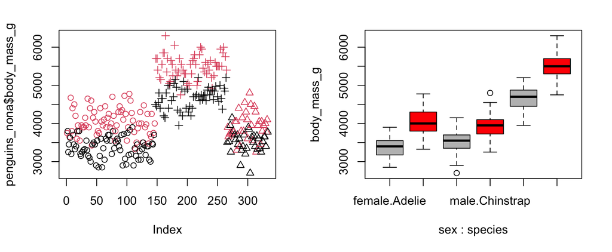

## Model

Observation $i$ of group $k$ in factor 1 and group $l$ in factor 2 is written as:
$$y_{i,k,l} = \mu + \alpha_k + \beta_l + \gamma_{kl} + \epsilon_i$$

- $\mu$ the “grand mean” (intercept)
- $\alpha_k$ the specific effect of group $k$ in factor 1 ($1 \leq k \leq K$).
- $\beta_l$ the specific effect of group $l$ in factor 2 ($1 \leq l \leq L$).
- $\gamma_{kl}$ the interaction effect of groups $k$ and $l$.

The full model has regression matrix:
$${\small
\mathbf{X} =
(\mathbb{1},
\mathbb{1}_{S_1}, \dotsc, \mathbb{1}_{S_K},
\mathbb{1}_{T_1}, \dotsc, \mathbb{1}_{T_L},
\mathbb{1}_{S_1, T_1}, \dotsc, \mathbb{1}_{S_K, T_L}
)
}$$

$\to$ $1 + K + L + KL$ predictors. $\to$ not identifiable !

## Constraint : Groups 1 as reference

$$y_{i,k,l} = \mu + \alpha_k + \beta_l + \gamma_{kl} + \epsilon_i$$

Assume, for all $1\leq k \leq K$ and $1\leq l \leq L$:
$$\alpha_1 = 0,
\qquad \beta_1 = 0,
\qquad \gamma_{1,l} = 0,
\qquad \gamma_{k,1} = 0.$$

- $y_{i,1,1}$ has mean $\mu$ (reference)
- $y_{i,1,l}$ has mean $\mu + \beta_l$
- $y_{i,k,1}$ has mean $\mu + \alpha_k$
- $y_{i,k,l}$ has mean $\mu + \alpha_k + \beta_l + \gamma_{k,l}$ ($k,l>1$)
- $1 + K + L$ constraints $\to$ $KL$ free parameters
- $\mathbf{X} = (\mathbb{1}, \mathbb{1}_{S_2}, \dotsc, \mathbb{1}_{S_K}, \mathbb{1}_{T_2}, \dotsc, \mathbb{1}_{T_L}, \mathbb{1}_{S_2, T_2}, \dotsc, \mathbb{1}_{S_K, T_L})$ full

$\to$ This is the constraint used by default in `R`.

## Species and Sex

```r
fit <- lm(body_mass_g ~  species * sex, data = penguins_nona)
summary(fit)
```

```
Call:
lm(formula = body_mass_g ~ species * sex, data = penguins_nona)

Residuals:
    Min      1Q  Median      3Q     Max
-827.21 -213.97   11.03  206.51  861.03

Coefficients:
                         Estimate Std. Error t value Pr(>|t|)
(Intercept)               3368.84      36.21  93.030  < 2e-16 ***
speciesChinstrap           158.37      64.24   2.465  0.01420 *
speciesGentoo             1310.91      54.42  24.088  < 2e-16 ***
sexmale                    674.66      51.21  13.174  < 2e-16 ***
speciesChinstrap:sexmale  -262.89      90.85  -2.894  0.00406 **
speciesGentoo:sexmale      130.44      76.44   1.706  0.08886 .
---
Signif. codes:  0 '***' 0.001 '**' 0.01 '*' 0.05 '.' 0.1 ' ' 1

Residual standard error: 309.4 on 327 degrees of freedom
Multiple R-squared:  0.8546,    Adjusted R-squared:  0.8524
F-statistic: 384.3 on 5 and 327 DF,  p-value: < 2.2e-16
```

## Other constraint

$$y_{i,k,l} = \mu + \alpha_k + \beta_l + \gamma_{kl} + \epsilon_i$$

**Interactions only**: for all $1\leq k \leq K$ and $1\leq l \leq L$:
$$\mu = 0,\qquad
\alpha_k = 0,
\qquad \beta_l = 0.$$

**Null sum**:
$$\sum_{k=1}^K\alpha_k = 0,
\qquad \sum_{l=1}^L\beta_l = 0,
\qquad \sum_{k=1}^K\gamma_{kl} = 0,
\qquad \sum_{l=1}^L\gamma_{kl} = 0.$$

$\to$ changes the estimation of the coefficients, but not of the variance, nor the predicted values.

## Nested F Test - Reminder

Recall that (from CM5), in general, to test:
$$\begin{aligned}
\mathcal{H}_0&: \beta_{p_0 + 1} = \cdots = \beta_p = 0 &\text{vs}\\
\mathcal{H}_1&: \exists~k\in \{p_0+1, \dotsc, p\} ~|~ \beta_k \neq 0
\end{aligned}$$

We can use the statistic:
$$F = \frac{
\|\hat{\mathbf{y}} - \hat{\mathbf{y}}_0\|^2 / (p - p_0)
}{
\|\mathbf{y} - \hat{\mathbf{y}}\|^2 / (n - p)
}
= \frac{n - p}{p - p_0}\frac{RSS_0 - RSS}{RSS}
\underset{\mathcal{H}_0}{\sim}
\mathcal{F}^{p - p_0}_{n - p}.$$

Writing $\mathbf{X}_{p_0} = (\mathbf{X}_1, \dotsc, \mathbf{X}_{p_0})$, this is the same as testing:
$$\begin{aligned}
\mathcal{H}_0&: \mathbf{P}^{\mathbf{X}_{p_0}}\mathbf{y} = \mathbf{P}^{\mathbf{X}}\mathbf{y} &\text{vs}\\
\mathcal{H}_1&: \mathbf{P}^{\mathbf{X}_{p_0}}\mathbf{y} \neq \mathbf{P}^{\mathbf{X}}\mathbf{y}
\end{aligned}$$

## Nested F Test - Reminder

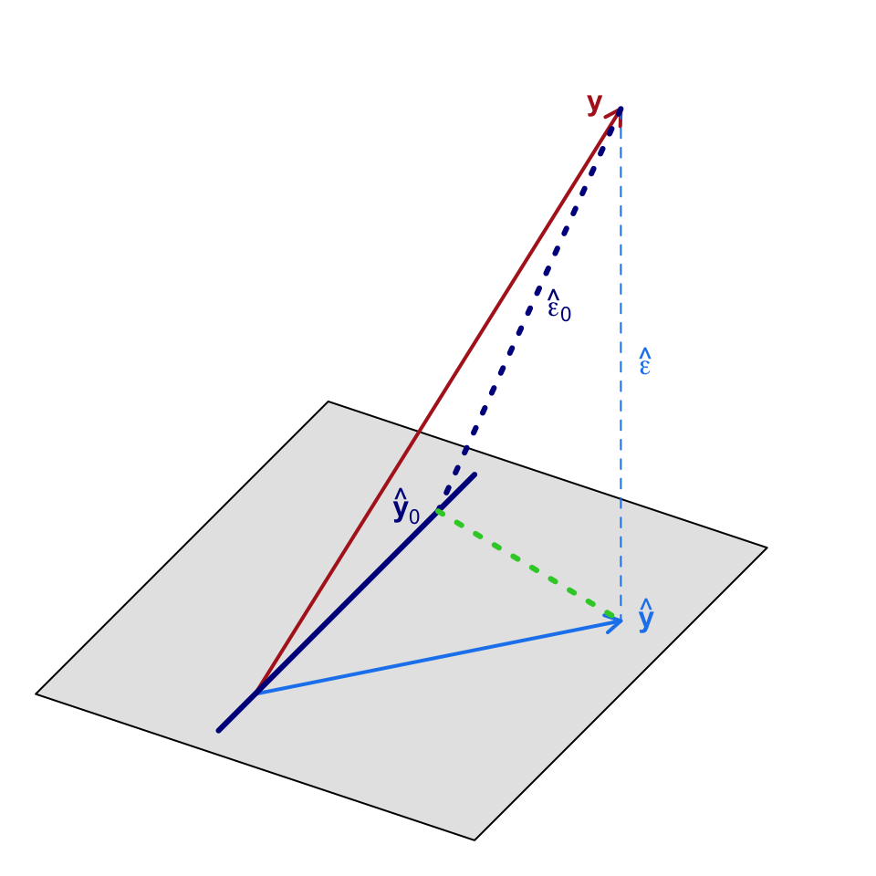

## Nested F Test - General

Take any two **nested** subsets of indexes $\eta_1 \subset \eta_2$, and write:
$$\begin{aligned}
\mathbf{X}_{\eta_k} &= (\mathbf{X}_i)_{i\in\eta_k}
& \mathbf{P}^{\mathbf{X}_{\eta_k}}\mathbf{y} &= \hat{\mathbf{y}}_{\eta_k}
& \mathbf{P}^{\mathbf{X}}\mathbf{y} &= \hat{\mathbf{y}}
\end{aligned}$$

To test:
$$\begin{aligned}
\mathcal{H}_0&: \text{"Larger model 2 does not bring any information compared to model 1"}\\
\mathcal{H}_1&: \text{"Larger model 2 does bring some information compared to model 1"}
\end{aligned}$$

i.e.
$$\begin{aligned}
\mathcal{H}_0&: \mathbf{P}^{\mathbf{X}_{\eta_1}}\mathbf{y} = \mathbf{P}^{\mathbf{X}_{\eta_2}}\mathbf{y} &\text{v.s.}&&
\mathcal{H}_1&: \mathbf{P}^{\mathbf{X}_{\eta_1}}\mathbf{y} \neq \mathbf{P}^{\mathbf{X}_{\eta_2}}\mathbf{y}
\end{aligned}$$

We can use:
$$F
= \frac{
\|\hat{\mathbf{y}}_{\eta_2} - \hat{\mathbf{y}}_{\eta_1}\|^2 / (|\eta_2| - |\eta_1|)
}{
\|\mathbf{y} - \hat{\mathbf{y}}\|^2 / (n - p)
}
= \frac{
1
}{
\hat{\sigma}^2
}
(RSS_{\eta_1} - RSS_{\eta_2}) / (|\eta_2| - |\eta_1|)
\underset{\mathcal{H}_0}{\sim}
\mathcal{F}^{|\eta_2| - |\eta_1|}_{n - p}.$$

## Anova model

**Model**:
$$y_{i,k,l} = \mu + \alpha_k + \beta_l + \gamma_{kl} + \epsilon_i$$
with, for all $1\leq k \leq K$ and $1\leq l \leq L$:
$$\alpha_1 = 0,
\qquad \beta_1 = 0,
\qquad \gamma_{1,l} = 0,
\qquad \gamma_{k,1} = 0.$$
($\to KL$ free parameters in total.)

**Tests**:

- Is factor 1 useful ?
- Is factor 2 useful ?
- Is the interaction between factor 1 and 2 useful ?

## Nested F Test - Anova - Factor 1

To test:
$$\begin{aligned}
\mathcal{H}_0&: \mathbf{P}^{\mathbf{X}_{\mu}}\mathbf{y} = \mathbf{P}^{\mathbf{X}_{\mu,\alpha}}\mathbf{y} &\text{v.s.}&&
\mathcal{H}_1&: \mathbf{P}^{\mathbf{X}_{\mu}}\mathbf{y} \neq \mathbf{P}^{\mathbf{X}_{\mu,\alpha}}\mathbf{y}
\end{aligned}$$
i.e. $\mathcal{H}_0$: “factor 1 does not bring any information compared to intercept alone”.

We can use:
$$\begin{aligned}
F
&= \frac{n - KL}{K - 1}\frac{RSS_{\mu} - RSS_{\mu, \alpha}}{RSS}\\
&= \frac{R(\alpha | \mu) / (K - 1)}{\hat{\sigma}^2}\\
&\underset{\mathcal{H}_0}{\sim}
\mathcal{F}^{K - 1}_{n - KL}.
\end{aligned}$$

## Nested F Test - Anova - Factor 2

To test:
$$\begin{aligned}
\mathcal{H}_0&: \mathbf{P}^{\mathbf{X}_{\mu,\alpha}}\mathbf{y} = \mathbf{P}^{\mathbf{X}_{\mu,\alpha, \beta}}\mathbf{y} &\text{v.s.}&&
\mathcal{H}_1&: \mathbf{P}^{\mathbf{X}_{\mu,\alpha}}\mathbf{y} \neq \mathbf{P}^{\mathbf{X}_{\mu,\alpha,\beta}}\mathbf{y}
\end{aligned}$$
i.e. $\mathcal{H}_0$: “factor 2 does not bring any information compared to factor 1”.

We can use:
$$\begin{aligned}
F
&= \frac{n - KL}{L - 1}\frac{RSS_{\mu, \alpha} - RSS_{\mu, \alpha, \beta}}{RSS}\\
&= \frac{R(\beta | \mu, \alpha) / (L - 1)}{\hat{\sigma}^2}\\
&\underset{\mathcal{H}_0}{\sim}
\mathcal{F}^{L - 1}_{n - KL}.
\end{aligned}$$

## Nested F Test - Anova - Interaction

To test:
$$\begin{aligned}
\mathcal{H}_0&: \mathbf{P}^{\mathbf{X}_{\mu,\alpha,\beta}}\mathbf{y} = \mathbf{P}^{\mathbf{X}_{\mu,\alpha, \beta,\gamma}}\mathbf{y} &\text{v.s.}&&
\mathcal{H}_1&: \mathbf{P}^{\mathbf{X}_{\mu,\alpha,\gamma}}\mathbf{y} \neq \mathbf{P}^{\mathbf{X}_{\mu,\alpha,\beta,\gamma}}\mathbf{y}
\end{aligned}$$
i.e. $\mathcal{H}_0$: “Interactions do not bring any information compared to factors 1 and 2”.

We can use:
$$\begin{aligned}
F
&= \frac{n - KL}{(L - 1)(K - 1)}\frac{RSS_{\mu, \alpha, \beta} - RSS_{\mu, \alpha, \beta, \gamma}}{RSS}\\
&= \frac{R(\gamma | \mu, \alpha, \beta) / ((K - 1)(L - 1))}{\hat{\sigma}^2}\\
&\underset{\mathcal{H}_0}{\sim}
\mathcal{F}^{(K - 1)(L - 1)}_{n - KL}.
\end{aligned}$$

## Two-way ANOVA - Type I Table

**“Type I”** Anova table:

|  | df | SS | Mean SS | F | $p$ value |
| --- | --- | --- | --- | --- | --- |
| factor 1 | $K - 1$ | $R(\alpha\|\mu)$ | $R(\alpha\|\mu) / df$ | $\hat{\sigma}^{-2} R(\alpha\|\mu) / df$ | $p$ |
| factor 2 | $L - 1$ | $R(\beta\|\mu, \alpha)$ | $R(\beta\|\mu, \alpha) / df$ | $\hat{\sigma}^{-2} R(\beta\|\mu, \alpha) / df$ | $p$ |
| interactions | $(K - 1)(L - 1)$ | $R(\gamma\|\mu, \alpha, \beta)$ | $R(\gamma\|\mu, \alpha, \beta) / df$ | $\hat{\sigma}^{-2} R(\gamma\|\mu, \alpha, \beta) / df$ | $p$ |
| residuals | $n - KL$ | $RSS$ | $\hat{\sigma}^2 = RSS / df$ |  |  |

## Species and Sex - Type I

```r
fit <- lm(body_mass_g ~  species * sex, data = penguins_nona)
anova(fit)
```

```
Analysis of Variance Table

Response: body_mass_g
             Df    Sum Sq  Mean Sq F value    Pr(>F)
species       2 145190219 72595110 758.358 < 2.2e-16 ***
sex           1  37090262 37090262 387.460 < 2.2e-16 ***
species:sex   2   1676557   838278   8.757 0.0001973 ***
Residuals   327  31302628    95727
---
Signif. codes:  0 '***' 0.001 '**' 0.01 '*' 0.05 '.' 0.1 ' ' 1
```

## Sex and Species - Type I

```r
fit <- lm(body_mass_g ~  sex * species, data = penguins_nona)
anova(fit)
```

```
Analysis of Variance Table

Response: body_mass_g
             Df    Sum Sq  Mean Sq F value    Pr(>F)
sex           1  38878897 38878897 406.145 < 2.2e-16 ***
species       2 143401584 71700792 749.016 < 2.2e-16 ***
sex:species   2   1676557   838278   8.757 0.0001973 ***
Residuals   327  31302628    95727
---
Signif. codes:  0 '***' 0.001 '**' 0.01 '*' 0.05 '.' 0.1 ' ' 1
```

## Two-way ANOVA - Type I Table

**“Type I”** Anova table:

|  | Df | SS | Mean SS | F | $p$ value |
| --- | --- | --- | --- | --- | --- |
| factor 1 | $K - 1$ | $R(\alpha\|\mu)$ | $R(\alpha\|\mu) / df$ | $\hat{\sigma}^{-2} R(\alpha\|\mu) / df$ | $p$ |
| factor 2 | $L - 1$ | $R(\beta\|\mu, \alpha)$ | $R(\beta\|\mu, \alpha) / df$ | $\hat{\sigma}^{-2} R(\beta\|\mu, \alpha) / df$ | $p$ |
| interactions | $(K - 1)(L - 1)$ | $R(\gamma\|\mu, \alpha, \beta)$ | $R(\gamma\|\mu, \alpha, \beta) / df$ | $\hat{\sigma}^{-2} R(\gamma\|\mu, \alpha, \beta) / df$ | $p$ |
| residuals | $n - KL$ | $RSS$ | $\hat{\sigma}^2 = RSS / df$ |  |  |

**Attention**: The order of factors matters !

## Two-way ANOVA - Type II Table

**“Type II”** Anova table:

|  | Df | SS | Mean SS | F | $p$ value |
| --- | --- | --- | --- | --- | --- |
| factor 1 | $K - 1$ | $R(\alpha\|\mu, \beta)$ | $R(\alpha\|\mu, \beta) / df$ | $\hat{\sigma}^{-2} R(\alpha\|\mu, \beta) / df$ | $p$ |
| factor 2 | $L - 1$ | $R(\beta\|\mu, \alpha)$ | $R(\beta\|\mu, \alpha) / df$ | $\hat{\sigma}^{-2} R(\beta\|\mu, \alpha) / df$ | $p$ |
| interactions | $(K - 1)(L - 1)$ | $R(\gamma\|\mu, \alpha, \beta)$ | $R(\gamma\|\mu, \alpha, \beta) / df$ | $\hat{\sigma}^{-2} R(\gamma\|\mu, \alpha, \beta) / df$ | $p$ |
| residuals | $n - KL$ | $RSS$ | $\hat{\sigma}^2 = RSS / df$ |  |  |

**Symmetric** in factor 1 and 2.

## Sex and Species - Type II

```r
fit <- lm(body_mass_g ~  sex * species, data = penguins_nona)
car::Anova(fit)
```

```
Anova Table (Type II tests)

Response: body_mass_g
               Sum Sq  Df F value    Pr(>F)
sex          37090262   1 387.460 < 2.2e-16 ***
species     143401584   2 749.016 < 2.2e-16 ***
sex:species   1676557   2   8.757 0.0001973 ***
Residuals    31302628 327
---
Signif. codes:  0 '***' 0.001 '**' 0.01 '*' 0.05 '.' 0.1 ' ' 1
```

## Bill Lenght - Type II

```r
fit <- lm(bill_length_mm ~  sex * species, data = penguins_nona)
car::Anova(fit)
```

```
Anova Table (Type II tests)

Response: bill_length_mm
            Sum Sq  Df  F value Pr(>F)
sex         1135.7   1 211.8066 <2e-16 ***
species     6975.6   2 650.4786 <2e-16 ***
sex:species   24.5   2   2.2841 0.1035
Residuals   1753.3 327
---
Signif. codes:  0 '***' 0.001 '**' 0.01 '*' 0.05 '.' 0.1 ' ' 1
```

## Bill Lenght - Type II - No interaction

```r
fit <- lm(bill_length_mm ~  sex + species, data = penguins_nona)
car::Anova(fit)
```

```
Anova Table (Type II tests)

Response: bill_length_mm
          Sum Sq  Df F value    Pr(>F)
sex       1135.7   1  210.17 < 2.2e-16 ***
species   6975.6   2  645.44 < 2.2e-16 ***
Residuals 1777.8 329
---
Signif. codes:  0 '***' 0.001 '**' 0.01 '*' 0.05 '.' 0.1 ' ' 1
```

# ANCOVA

## Penguins

**Question**: what is the relationship between bill length and depth, controlling for the species ?

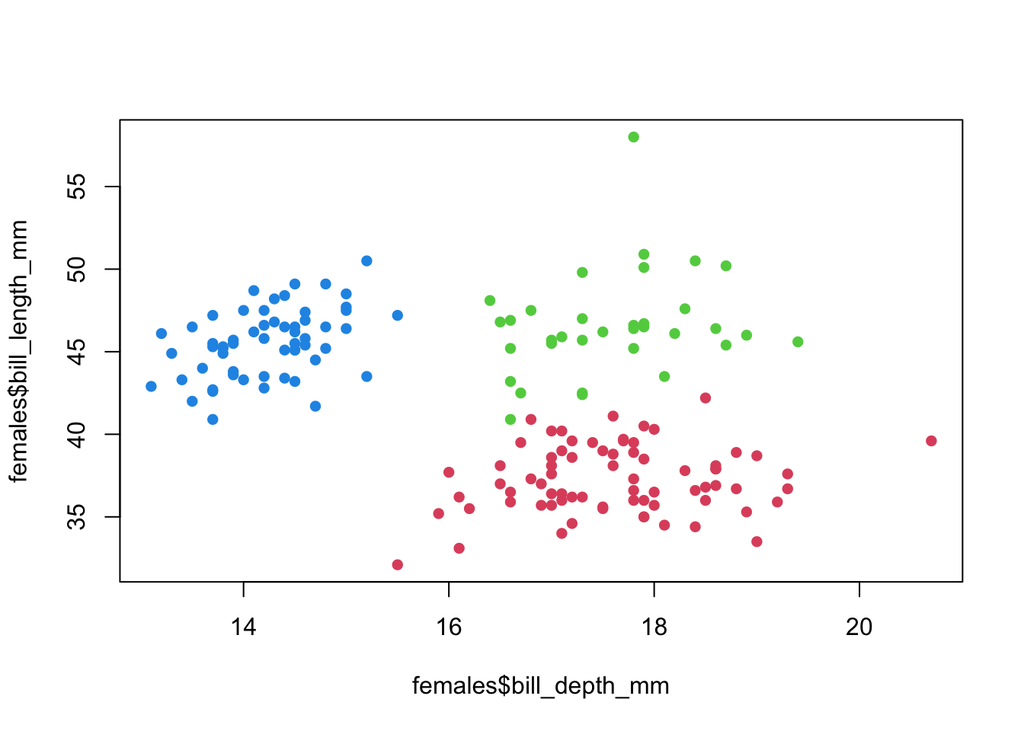

## One line fits all

```r
fit_all <- lm(bill_length_mm ~ bill_depth_mm, data = females)
summary(fit_all)
```

```
Call:
lm(formula = bill_length_mm ~ bill_depth_mm, data = females)

Residuals:
     Min       1Q   Median       3Q      Max
-11.0745  -3.0689  -0.7609   2.6776  17.5034

Coefficients:
              Estimate Std. Error t value Pr(>|t|)
(Intercept)    61.2214     3.1966  19.152  < 2e-16 ***
bill_depth_mm  -1.1643     0.1935  -6.018 1.13e-08 ***
---
Signif. codes:  0 '***' 0.001 '**' 0.01 '*' 0.05 '.' 0.1 ' ' 1

Residual standard error: 4.449 on 163 degrees of freedom
Multiple R-squared:  0.1818,    Adjusted R-squared:  0.1768
F-statistic: 36.22 on 1 and 163 DF,  p-value: 1.128e-08
```

## One line fits all

$$y_{i} = \mu + \beta x_{i} + \epsilon_i$$

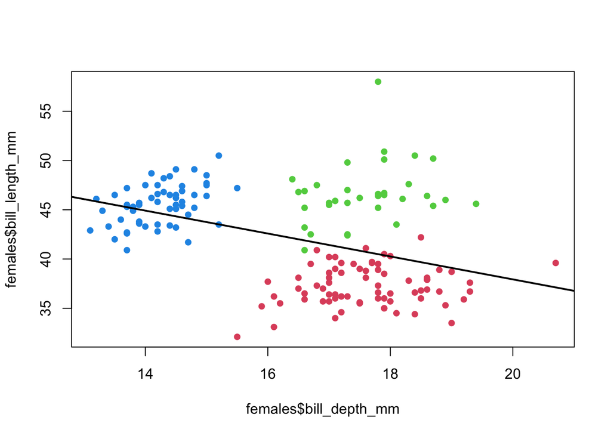

## Take species into account

```r
fit_species <- lm(bill_length_mm ~ bill_depth_mm + species, data = females)
summary(fit_species)
```

```
Call:
lm(formula = bill_length_mm ~ bill_depth_mm + species, data = females)

Residuals:
    Min      1Q  Median      3Q     Max
-4.9886 -1.4503 -0.0603  1.4476 11.2797

Coefficients:
                 Estimate Std. Error t value Pr(>|t|)
(Intercept)       25.0447     3.9377   6.360 1.99e-09 ***
bill_depth_mm      0.6930     0.2230   3.108  0.00222 **
speciesChinstrap   9.3393     0.4648  20.092  < 2e-16 ***
speciesGentoo     10.6515     0.8510  12.516  < 2e-16 ***
---
Signif. codes:  0 '***' 0.001 '**' 0.01 '*' 0.05 '.' 0.1 ' ' 1

Residual standard error: 2.238 on 161 degrees of freedom
Multiple R-squared:  0.7954,    Adjusted R-squared:  0.7916
F-statistic: 208.7 on 3 and 161 DF,  p-value: < 2.2e-16
```

## Take species into account

$$y_{i,k} = \mu + \alpha_k + \beta x_{i} + \epsilon_i$$

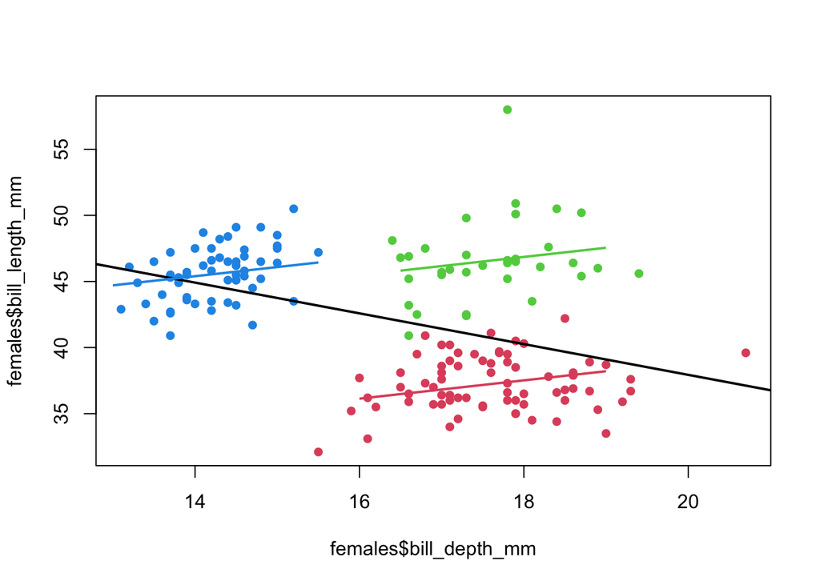

## Take species into account

```r
fit_species <- lm(bill_length_mm ~ bill_depth_mm + species, data = females)
car::Anova(fit_species)
```

```
Anova Table (Type II tests)

Response: bill_length_mm
               Sum Sq  Df  F value    Pr(>F)
bill_depth_mm   48.41   1   9.6624  0.002224 **
species       2419.64   2 241.4533 < 2.2e-16 ***
Residuals      806.70 161
---
Signif. codes:  0 '***' 0.001 '**' 0.01 '*' 0.05 '.' 0.1 ' ' 1
```

## Interactions

```r
fit_int <- lm(bill_length_mm ~ bill_depth_mm + species + bill_depth_mm:species,
              data = females)
fit_int
```

```
Call:
lm(formula = bill_length_mm ~ bill_depth_mm + species + bill_depth_mm:species,
    data = females)

Coefficients:
                   (Intercept)                   bill_depth_mm
                       31.1671                          0.3456
              speciesChinstrap                   speciesGentoo
                       -2.5348                         -8.8729
bill_depth_mm:speciesChinstrap     bill_depth_mm:speciesGentoo
                        0.6745                          1.2887
```

## Interactions

$$y_{i,k} = \mu + \alpha_k + \beta_k x_{i} + \epsilon_i$$

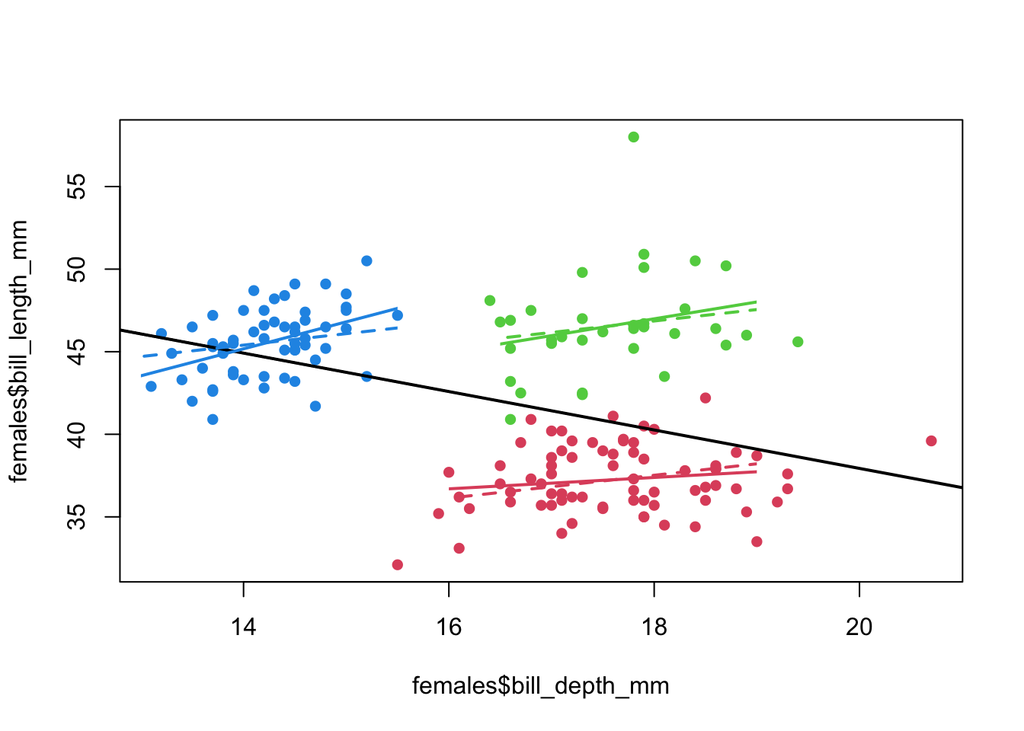

## Interactions

```r
fit_int <- lm(bill_length_mm ~ bill_depth_mm + species + bill_depth_mm:species,
              data = females)
car::Anova(fit_int)
```

```
Anova Table (Type II tests)

Response: bill_length_mm
                       Sum Sq  Df  F value    Pr(>F)
bill_depth_mm           48.41   1   9.8428  0.002032 **
species               2419.64   2 245.9610 < 2.2e-16 ***
bill_depth_mm:species   24.62   2   2.5029  0.085070 .
Residuals              782.08 159
---
Signif. codes:  0 '***' 0.001 '**' 0.01 '*' 0.05 '.' 0.1 ' ' 1
```

## Ancova - One Regressor - Model

For any observation $1 \leq i \leq n$ in group $1 \leq k \leq K$, we write:
$$y_{i,k} = \mu + \alpha_k + (\beta + \gamma_k) \times x_{i} + \epsilon_i
\qquad
\epsilon_i\sim\mathcal{N}(0, \sigma^2)~iid$$

**Identifiability**: $\alpha_1 = \gamma_1 = 0$.

$$\text{With $K=2$:}\qquad
\mathbf{X} =
\begin{pmatrix}
1 & 0 & x_1 & 0\\
\vdots & \vdots & \vdots & \vdots\\
1 & 0 & x_{n_1} & 0 &\\
1 & 1 & x_{n_1 + 1} & x_{n_1 + 1} \\
\vdots & \vdots & \vdots & \vdots\\
1 & 1 & x_{n_1 + n_2} & x_{n_1 + n_2}\\
\end{pmatrix}$$

## Ancova

F tests of effects and interactions can be done as before

More than one predictor ? $\to$ not a problem

More than one factor ? $\to$ not a problem

**Attention** as model become more complex, they are more difficult to interpret and test.

**Attention** diagnostics on the residuals still needed.

## Bill length and depth

```r
fit_species <- lm(bill_length_mm ~ bill_depth_mm + species, data = females)
par(mfrow = c(2,2))
plot(fit_species)
```

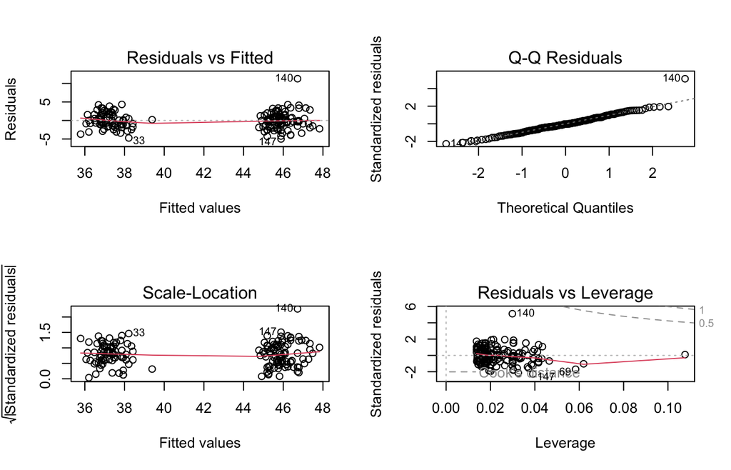